# R Notebook

## Base Graphics

### Plotting function

if x and y are **vectors**, it produces a scatter-plot of x against y:

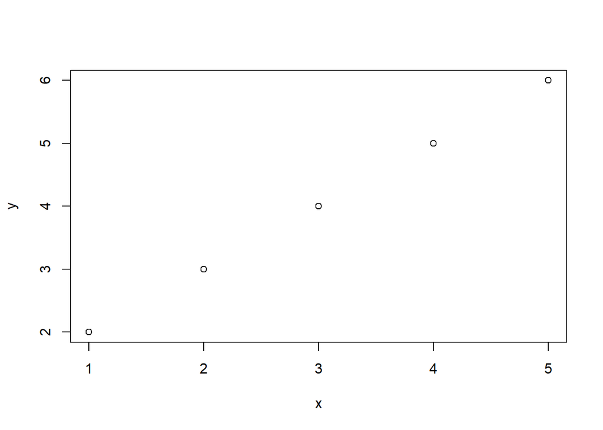

```r
x = c(1, 2, 3, 4, 5)
y = c(2, 3, 4, 5, 6)

plot(x, y)
```

if x is a **time series**, it produces a time-series plot:

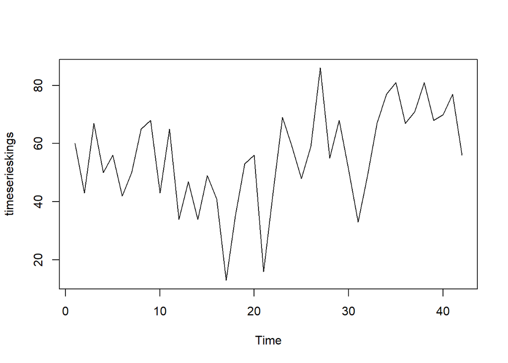

```r
kings <- scan("http://robjhyndman.com/tsdldata/misc/kings.dat",skip=3)

timeserieskings <- ts(kings)

plot(timeserieskings)
```

If x is a **numeric vector**, it produces a plot of the values in the vector against their index in the vector:

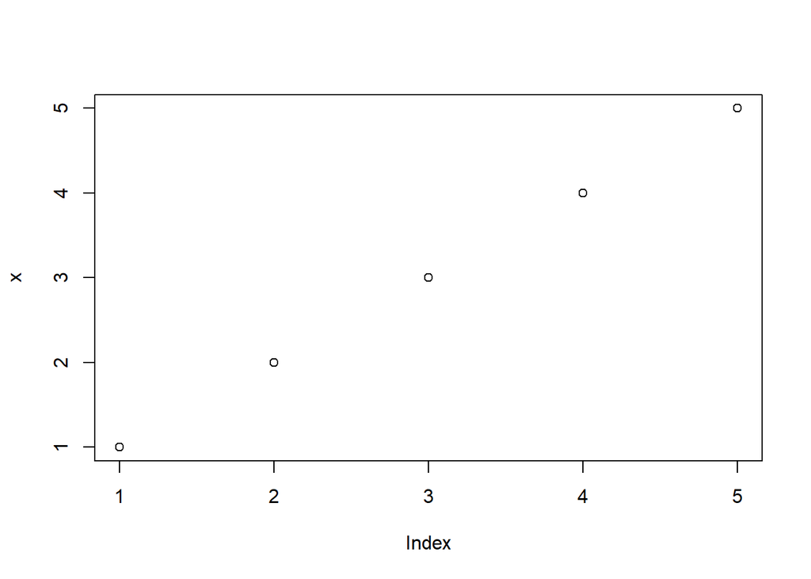

```r
x = c(1, 2, 3, 4, 5)

plot(x)
```

if x is a **complex vector**, it produces a plot of imaginary versus real parts of the vector elements

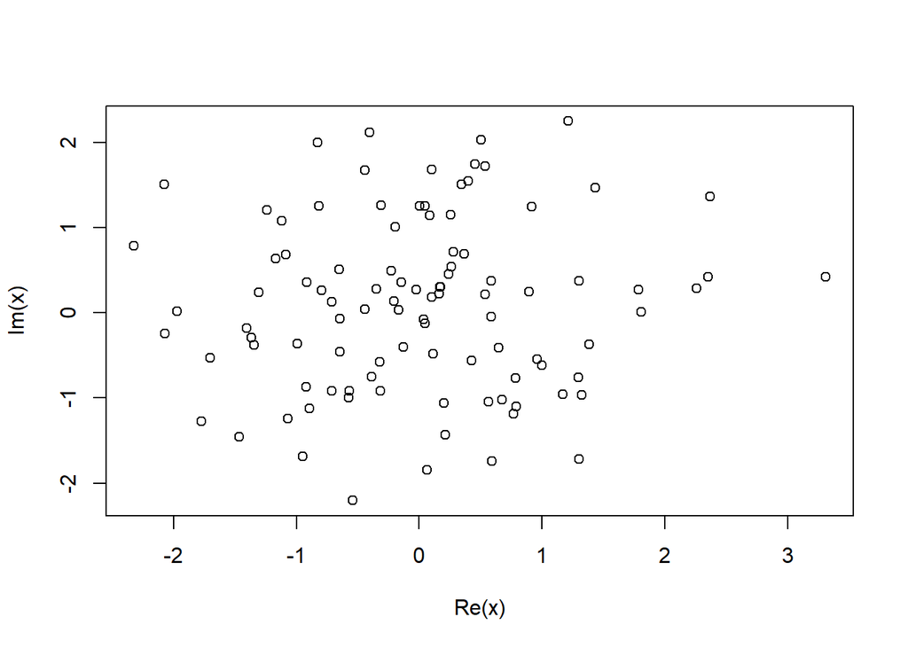

```r
x = complex(real = rnorm(100), imag = rnorm(100))

plot(x)
```

`plot(f)`, with f = factor, generates a bar plot of f

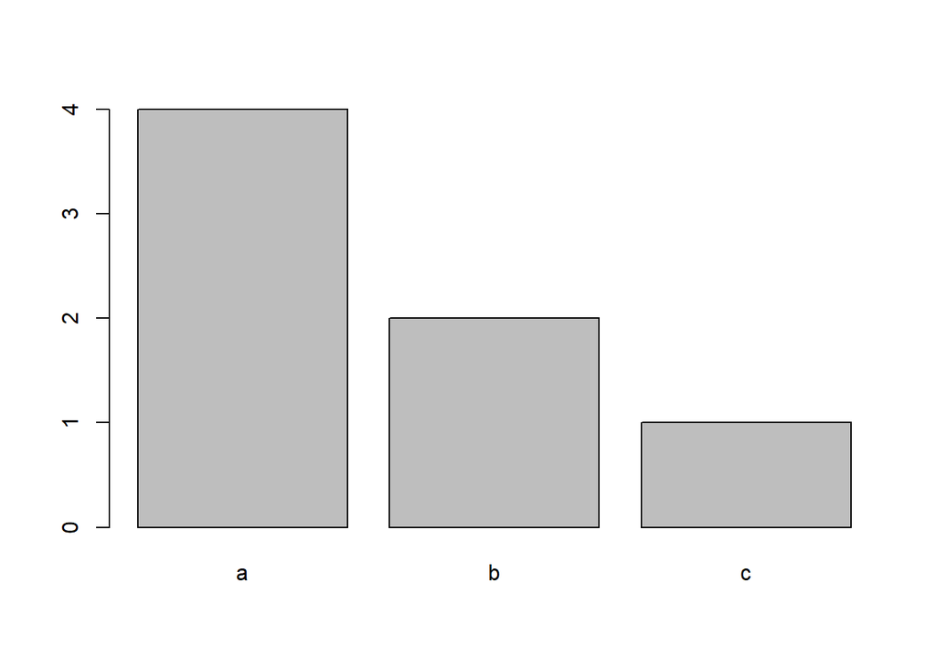

```r
f = as.factor(c('a', 'a', 'b', 'c', 'a', 'a', 'b'))

plot(f)
```

`plot(f, y)`, with f = factor, y = numeric vector generates box-plots of y for each level of f

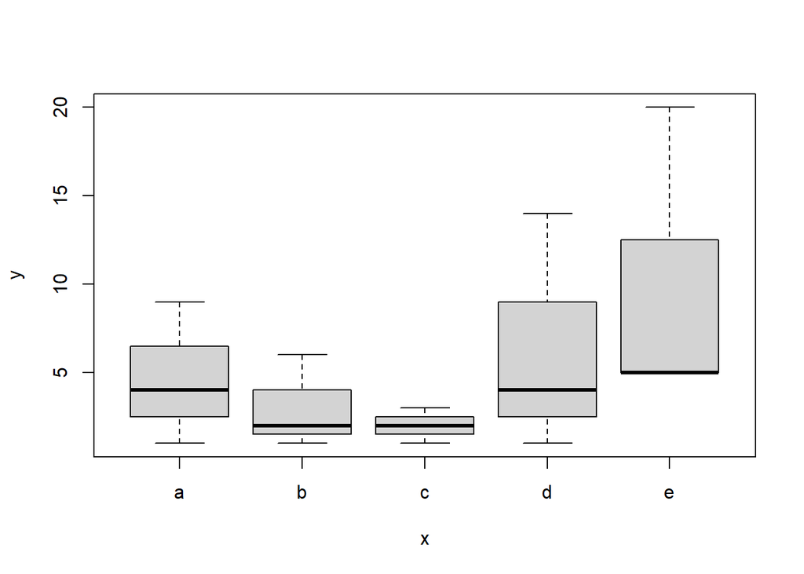

```r
y = c(1, 2, 3, 4, 5, 4, 9, 6, 2, 14, 5, 1, 1, 1, 20)
f = as.factor(c('a', 'b', 'c', 'd', 'e', 'a', 'a', 'b', 'c', 'd', 'e', 'b', 'c', 'd', 'e'))

plot(f, y)
```

`plot(df)`, with df = dataframe produces distributional plots of the variables in a dataframe

`plot(~ expr)` produces distributional plots of a number of named objects

`plot(y ~ expr)`, plots y against each object named in expr

## Multivariate Data

R provides two functions for representing multivariate data.

If X is a numeric matrix or dataframe, with `pairs(x)`. This produces a pairwise scatterplot matrix of the variables defined by the columns of X, that is, every column of X is plotted against every other column of X.

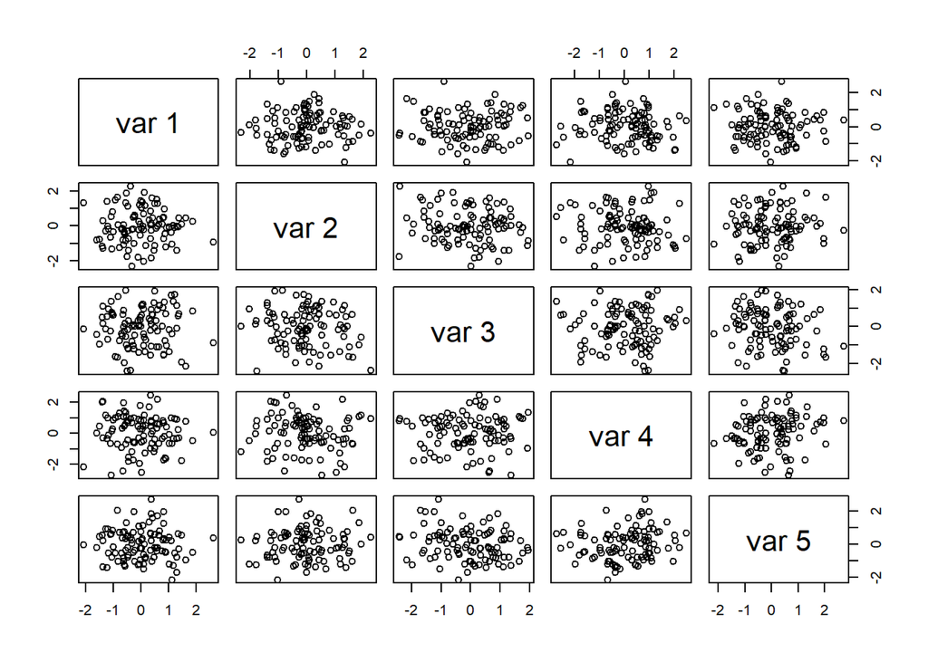

```r
x = x <- matrix(rnorm(500), 100, 5)

pairs(x)
```

- If `a` and `b` are numeric vectors and `c` is a numeric vector or factor object, then:

`coplot(a ~ b | c)`

produces a number of scatterplots of `a` against `b` for given values of `c`.

- If `c` is a factor

`coplot(a ~ b | c)`

means that `a` is plotted against `b` for every level of `c`.

- if `c` is numeric, it is divided into a number of conditioning intervals and for each interval `a` is plotted against `b` for the values of `c` within the interval. The number and position of intervals can be controlled with `given.values=` arguments to `coplot()` - the function `co.intervals()` is useful for selecting intervals. You can also use two given variables with a command like:

`coplot(a ~ b | c + d)` which produces scatterplots of `a` against `b` for every joint conditioning interval of `c` and `d`

Both `coplot()` and `pairs()` take an argument `panel=` which can be used to customize the type of plot which appears in each panel. The default one is `points()` to produce a scatterplot but by supplying some other low-level graphics function of two vectors `x` and `y` as the value of `panel=` you can produce any type of plot you wish. An example panel function useful for coplots is `panel.smooth()`.

## Other high-level plotting functions

`qqnorm(x)`, plots the numeric vector `x` against the expected Normal order scores

`qqline(x)`, adds a straight line to such a plot by drawing a line through the distribution and data quartiles.

`qqplot(x)`, plots the quantiles of `x` against those of `y` to compare their respective distributions

`hist(x)`, produces a histogram of the numeric vector x. A sensible number of classes is usually chosen.

`hist(x, nclass = n)`, recommendation for the number of classes.

`hist(x, breaks = b, ...)`, exact number of breakpoints.

If `probability = True` is given, the bars represent relative frequencies divided by bin width instead of counts.

`dotchart(x, ...)` construct a dot-chart of the data in `x`. The y-axis gives a labeling of the data in `x` and the x-axis gives its value

Plots of three variables:

`image(x, y, z, ...)` grid of rectangles using different colors to represent the value of `z`.

`contour(x, y, z, ...)` draws contour lines to represent the value of `z`

`persp(x, y, z, ...)` draws a 3D surface.

## Arguments to high-level plotting functions

`add = True` forces the function to act as a low-level graphics function, superimposing the plot on the current plot

`axes = False` suppress the the generation of the axes

`log='x'`, `log='y'`, `log='xy'` causes the x, y or both axes to be log.

`type=` controls the type of plot produced, as follows:

- `type = 'p'` plot individual *points* (default)
- `type = 'l'` plot *lines*
- `type = 'b'` plots *both* points and lines
- `type = 'o'` plots points overlaid by lines
- `type = 's'` step-function plot where the top of the vertical defines the points
- `type = 'S'` step-function plot where the bottom defines the points
- `type = 'n'` No plotting at all

`xlab = string` and `ylab = string` defines the axis labels for x and y.

`main = string` defines the title

`sub = string` define the sub-title

## Low-level plotting functions

To add points/lines to the current plot:

`points(x, y)`

`lines(x, y)`

To add text to a plot at given x, y positions:

`text(x, y, labels, ...)`

To add a line:

`abline(a, b)`, where `a` is the intercept, `b` is the slope

`abline(h = y)`, to plot a horizontal line

`abline(v = x)`, to plot a vertical line

`abline(lm.obj)`, to plot a line starting from a linear model’s coefficients

`polygon(x, y, ...)` draws a polygon defined by the ordered vertices in `(x, y)` and optionally shade it in with hatch lines, or fill it if the graphics device allows the filling of figures.

`legend(x, y, legend, ...)` add a legend to the current plot at the specified position. Plotting characters, line styles, colors, etc., are identified with the labels in the character vector `legend`. At least one other argument `v` (a vector the same length as `legend`) with the corresponding values of the plotting unit must also be given, as follows:

`legend(, fill = v)` colors for filled boxes

`legend(, col = v)` colors in which points or lines will be drawn

`legend(, lty = v)` line styles

`legend(, lwd = v)` line widths

`legend(, pch = v)` plotting characters (character vector)

`title(main, sub)` adds a title `main` on top and an optional subtitle `sub` at the bottom.

`axis(side, ...)` adds an axis to the current plot on the side given by the first argument (1 to 4, counting clockwise from the bottom)

Low-level plotting functions usually require some positioning information (e.g., x and y coordinates) to determine where to place the new plot elements. Coordinates are given in terms of user coordinates which are defined by the previous high-level graphics command and are chosen based on the supplied data.

Where x and y arguments are required, it is also sufficient to supply a single argument being a list with elements named x and y. Similarly, a matrix with 2 columns is also valid input. In this way functions such as `locator()` may be used to specify positions on a plot interactively.

## Mathematical annotations

example

```
text(x, y, expression(paste(bgroup("(", atop(n, x), ")"), p^x, q^{n-x})))
```

## Interacting with graphics

R also provides functions which allow to extract or add information to a plot using a mouse. The simplest of these is the `locator()` function:

`locator(n , type)`, it allows to wait for the user to select locations on the current plot using the left mouse button. This continues until `n` points have been selected, or another mouse button is pressed. The `type` argument allows for plotting at the selected points and has the same effect as for high-level graphics commands; the default is no plotting. `locator()` returns the locations of the points selected as a list with two components `x` and `y`.

`identify(x, y, labels)` allow the user to highlight any of the points defined by x and y (using the left-mouse button) by plotting the corresponding component of `labels` nearby (or the index number of the point if `labels` is absent). Returns the indices of the selected points when another button is pressed.

## Graphics parameters

### Permament Changes

`par` function, used to access and modify the list of graphics parameters for the current graphics device

usually used as `par(mfrow = c(nrows, ncols))`

### Temporary Changes

an example is `plot(x, y, pch = '+')`, that produces a scatter-plot with a plus sign as plotting character.

## Graphical elements

`pch = '+'`, char to be used for plotting points

`pch = 4`, accepts integers between 0 and 25 (included) and produces a certain plotting symbol

`lty = 0`, invisible line `lty = 1`, solid line `lty = 2`, dotted or dashed lines from 2+

`lwd = 2`, sets the width of the line

`col = 2`, colors to be used for points, lines, text, filled regions and images. A number from the current palette or a named color.

`col.axis`, `col.lab`, `col.main`, `col.sub`, colors to be used for axis annotations, x and y labels, main and sub titles respectively.

`font = 2`, an integer which specifies which font to use for text: - **1**, plain text - **2**, bold face - **3**, italic - **4**, bold italic - **5**, symbol font.

`font.axis`, `font.lab`, `font.main`, `font.sub`, font to be used for axis annotation, x and y labels, main and sub titles respectively.

`adj = -0.1`, justification of text relative to the plotting position: - **0**, left justify - **1**, right justify - **0.5**, center horizontally - **-0.1**, gap 0f 10% of the text width between the text and the plotting position

`cex = 1.5`, character expansion. The value is the desired size of text characters (including plotting characters) relative to the default text size

`cex.axis`, `cex.lab`, `cex.main`, `cex.sub`, the character expansion to be used for axis annotation, x and y labels, main and sub titles, respectively.

## Axes and tick marks

`lab = c(5, 7, 12)`, the **first two** numbers are the desired number of tick intervals on the x and y axes respectively; the **third** number is the desired length of axis labels, in characters (including decimal points).

`las = 1`, orientation of axis labels: - **0**, parallel to axis - **1**, horizontal to axis - **2**, perpendicular to axis

`mgp = c(3, 1, 0)`, positions of axis components. The **first** component is the distance from the axis label to the axis position, in text lines. The **second** component is the distance to the tick labels. The **third** component is the distance from the axis position to the axis line (usually zero). Negative values give tick marks outside the plotting region. `tck=0.01` and `mgp=c(1, -1.5, 0)` for internal tick marks.

`xaxs = 'r'`, `yaxs = 'i'`, axis styles for the x and y axes respectively: - `i`, internal - `r`, default

## Figure margins

`mai = c(1, 0.5, 0.5, 0)`, widths of the bottom, left, top and right margins, respectively, measured in **inches**.

`mar = c(4, 2, 2, 1)`, same as `mai` but measurement unit is **text lines**.

## Multiple figure environment

`mfcol = c(3, 2)`, `mfrow = c(2, 4)` set the size of a multiple figure array. The **first** value is the number of rows, the **second** is the number of columns. The difference is that `mfcol` causes figures to be filled by column. `mfrow` fills the rows.

`mfg = c(2, 2, 3, 2)`, position of the current figure in a multiple figure environment. The **first two** numbers are the row and column of the current figure, the **last two** are the number of rows and columns in the multiple figure array.

`fig = c(4, 9, 1, 4)/10`, position of the current figure on the page. Values are the position of the left, right, bottom and top edges respectively.

`oma = c(2, 0, 3, 0)`, `omi = c(0, 0, 0.8, 0)`, size of tyhe outer margins. Like `mar` and `mai`, the first measures in text lines and the second in inches, starting with the bottom margin and working clockwise.

## Device drivers

`X11()` for use with the X11 window system on Unix-alikes

`windows` for use on Windows

`quartz()` for use on macOS

`postscript()` for printing on PostScript printers, or creating PostScript graphics files.

`pdf()` produces a PDF file

`png()` produces a bitmap PNG file

`jpeg()` produces a bitmap JPEG file

When you have finished with a device, remember to terminate the device through `dev.off()`.

### Commands to control device drivers

`dev.list()`, returns the number and name of all active devices.

`dev.next()`, `dev.prev()`, returns the number and name of the graphics device next to, or previous to the current device, respectively.

`dev.set(which = k)`, can be used to change the current graphics device to the one at position k of the device list.

`dev.off(k)`, shut down the graphics device at point k of the device list.

`dev.copy(device, ..., which = k)`, `dev.print(device, ..., which = k)`, make a copy of the device k.

`graphics.off()`, terminate all graphics devices on the list.